# MATH 495 - Project #1

Richard Groenewald - 301263762

November 15th, 2018

```r
load("druguse.Rdata")
suppressMessages(require(dplyr))
suppressMessages(require(rpart))
suppressMessages(require(rpart.plot))
suppressMessages(require(ggplot2))
suppressMessages(require(randomForest))
suppressMessages(require(caret))
suppressMessages(require(mlbench))
suppressMessages(require(e1071))
suppressMessages(require(class))
suppressMessages(require(neuralnet))
suppressMessages(require(GGally))
suppressMessages(require(corrplot))
```

## Question 1

We explore the relationship between ethnicity and UseLevel:

```r
druguse %>% group_by(ethnicity,UseLevel) %>% tally()
```

```
## Source: local data frame [13 x 3]
## Groups: ethnicity [?]
##
##            ethnicity UseLevel     n
##               <fctr>   <fctr> <int>
## 1              Asian      low    19
## 2              Asian     high     7
## 3              Black      low    26
## 4              Black     high     7
## 5  Mixed-Black/Asian     high     3
## 6  Mixed-White/Asian      low     8
## 7  Mixed-White/Asian     high    12
## 8  Mixed-White/Black      low    10
## 9  Mixed-White/Black     high    10
## 10             Other      low    19
## 11             Other     high    44
## 12             White      low   767
## 13             White     high   953
```

We observe that individuals with *ethnicity* = white OR other have high use level signficantly more common than low use level.

And similarly for gender, noting that men appear to have a much larger proportion of high level drug users than women:

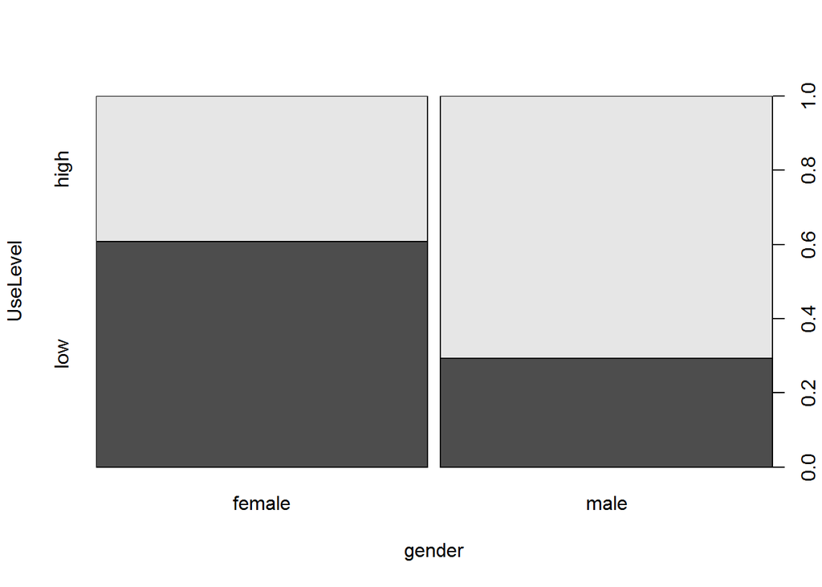

```r
plot(druguse$gender, druguse$UseLevel, xlab="gender", ylab="UseLevel")
```

We plot histograms of the the eight “continuous” variables to test graphically for normality (this is particularly important for applying a naive Bayes classifier below which assumes a Gaussian distribution for continuous variables). There seem to be some slight departures from this assumption in the cases of *education*, *impulsiveness* and *sensation*, but the remaining variables seem to satisfy it:

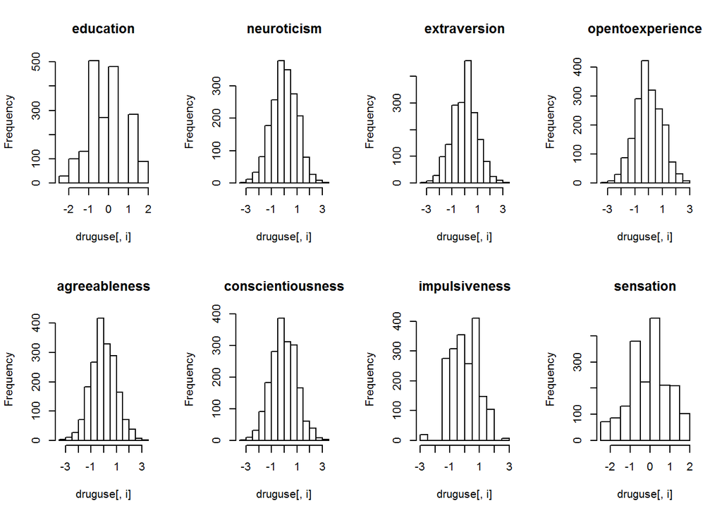

```r
par(mfrow = c(2,4))
indices = c(3, 6:12)
for(i in indices){
  hist(druguse[,i], main = colnames(druguse)[i])
}
```

```r
par(mfrow = c(1,1))
```

We produce a correplation plot between the illegal drugs to identify patterns that may be helpful in predicting one from several of the others (particularly for ideas in question 4):

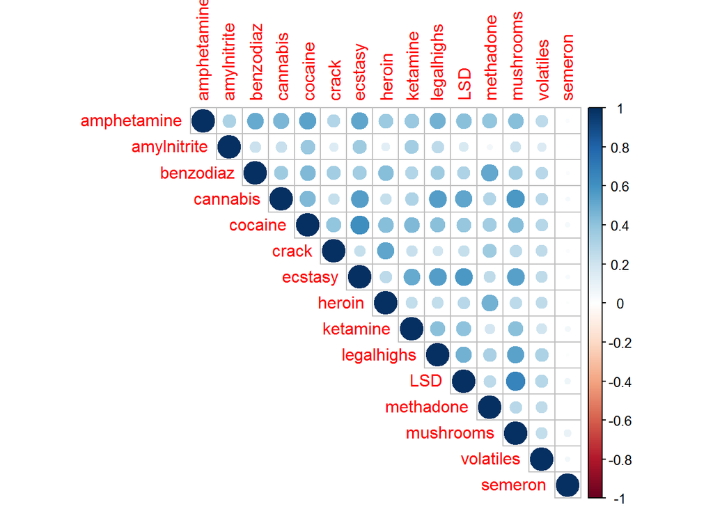

```r
corrs = cor(druguse[,17:31])
corrplot(corrs, type ="upper")
```

We note somewhat high correlation ($\approx 0.6$) between heroin and crack and heroin and benzodiaz. It is worth noting that there eappear to be no negative correlations among the different types of illegal drugs.

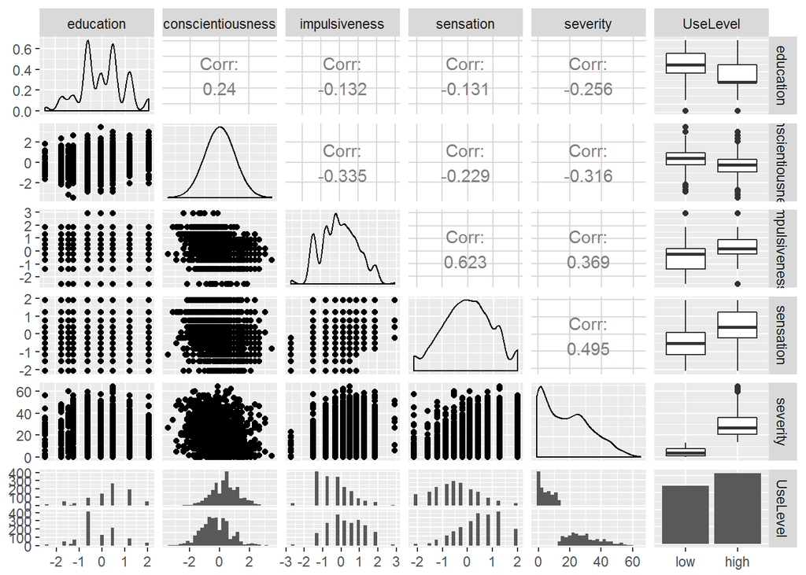

```r
ggpairs(druguse[,c(3,10:12,33,34)])
```

We note that based on the barplots in the above figure, UseLevel may be separated somewhat by *sensation*, *impulsiveness* and *education*. We also see mild/small correlations between all of these predictors and severity, which is surprising given their apparent relationship with *UseLevel*.

Looking ahead to problems 2 and 3, we first desire to limit the model space to a reasonable size (since the full space has $2^{16}$ total models due to our $16$ possible predictors - we do not consider interaction terms). While limiting the space will optimistically bias an estimate of test error later, we need to do so due to computational time. Particularly for problem 3, we determine **sets** of candidate variables using the *caret* package and stepwise logistic regression - choosing the sets with the lowest cross validated test error from the *caret* package and lowest Bayesian Information Criterion values from stepwise logistic regression, after which we will compare the test error of different learning methods on EACH set of variables. Choosing many sets helps reduce the bias.

```r
predictors = druguse[, 1:16] #extract relevant predictors/response
response = druguse[, 34]
full = druguse[,c(1:16,34)]
```

In the *caret* package, using the Recursive Feature Elimination (RFE) function:

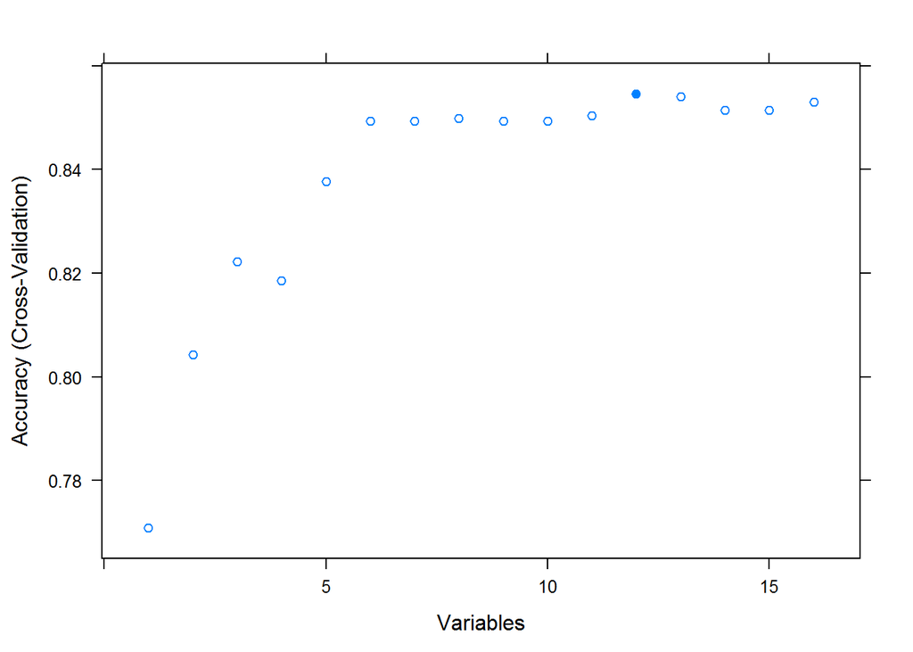

```r
set.seed(12345)
#5 fold CV with random forest method
controlset = rfeControl(functions = rfFuncs, method = "cv", number = 5)
 #compute estimated test error for each size of model - 1 variable to 16
res = rfe(predictors, response, size = 1:16, rfeControl = controlset)
plot(res)
```

```r
res$optVariables
```

```
##  [1] "nicotine"          "country"           "sensation"
##  [4] "opentoexperience"  "conscientiousness" "gender"
##  [7] "agegroup"          "education"         "impulsiveness"
## [10] "agreeableness"     "neuroticism"       "extraversion"
```

```r
#define matrix with TRUE/FALSE entries determining variable inclusion/exclusion
modelspace = matrix(ncol = 16, nrow = 13); colnames(modelspace) = colnames(predictors)
#extract variables from RFE
varmtx = res$variables[res$variables[,6]=="Fold1",4:5]
#fill space
for (i in 6:16){
  modelspace[i-5,] = (colnames(modelspace) %in% varmtx$var[varmtx$Variables==i])
}
```

We note from the plot of the estimated test error for each of the model sizes that models with the number of predictors larger than 5 appear to have high estimated test accuracy. We save the variables from models with 6 or more predictors for later use, and note the “best” model’s variables above.

We add two more sets of variables to the model space using the Akaike/Bayesian Information Criterion (AIC/BIC) (stepwise from intercept only model to reduce the number of fitted variables). $AIC(m) = -2log(L_m) + 2k$ and $BIC(m) = -2log(L_m) + k$log$(n)$, where $L_m$ is the realized likelihood of an arbitrary model $m$ which fits $k$ parameters with $n$ observed data points. We attempt to choose the model with minmimum $AIC$ or $BIC$ (selecting the minimum in a stepwise procedure).

```r
nullmod = glm(UseLevel~1, family=binomial(link="logit"), data=full)
#determine "bounds" for model variables
fullmod = glm(UseLevel~., family=binomial(link="logit"), data=full)

#fit with criteria
AICmod = step(nullmod, scope = list(lower=nullmod, upper=fullmod), direction="both", k=2, trace=FALSE)
BICmod = step(nullmod, scope = list(lower=nullmod, upper=fullmod), direction="both", k=log(nrow(full)), trace=FALSE)

#extract variable names
AICmodvars = all.vars(AICmod$formula)[-1]
BICmodvars = all.vars(BICmod$formula)[-1]

#add to model space for Q3
modelspace[12,] = colnames(modelspace) %in% AICmodvars
modelspace[13,] = colnames(modelspace) %in% BICmodvars
```

## Question 2

### 2.1

Based on the output from the *rfe* function above, and based on the desirability for interpretability in our initial approach, we fit a logistic regression model using the “best” subset of variables discovered via the test accuracy estimates in *rfe*.

```r
train = full[1:1500,]
test = full[1501:1885,]
form = as.formula(paste("UseLevel ~", paste(res$optVariables, collapse = " + ")))
form
```

```
## UseLevel ~ nicotine + country + sensation + opentoexperience +
##     conscientiousness + gender + agegroup + education + impulsiveness +
##     agreeableness + neuroticism + extraversion
```

```r
logregmod_q2 = glm(form, family = binomial(link="logit"), data=train) #fitted model
summary(logregmod_q2)
```

```
##
## Call:
## glm(formula = form, family = binomial(link = "logit"), data = train)
##
## Deviance Residuals:
##     Min       1Q   Median       3Q      Max
## -3.4803  -0.4097   0.1208   0.4270   2.8849
##
## Coefficients:
##                            Estimate Std. Error z value Pr(>|z|)
## (Intercept)               -0.006226   0.530913  -0.012 0.990643
## nicotine                   0.487909   0.037297  13.082  < 2e-16 ***
## countryCanada             -0.857596   0.617299  -1.389 0.164750
## countryNewZealand         -0.638589   1.489233  -0.429 0.668066
## countryOther              -1.335886   0.597736  -2.235 0.025423 *
## countryRepublicofIreland  -2.005239   0.881236  -2.275 0.022877 *
## countryUK                 -2.328460   0.508081  -4.583 4.59e-06 ***
## countryUSA                -0.145895   0.532432  -0.274 0.784072
## sensation                  0.702890   0.124375   5.651 1.59e-08 ***
## opentoexperience           0.585545   0.103403   5.663 1.49e-08 ***
## conscientiousness         -0.336936   0.100315  -3.359 0.000783 ***
## gendermale                 0.991588   0.177479   5.587 2.31e-08 ***
## agegroup25-34              0.321533   0.235950   1.363 0.172973
## agegroup35-44             -0.132670   0.243178  -0.546 0.585363
## agegroup45-54             -0.620625   0.261134  -2.377 0.017471 *
## agegroup55-64             -0.967433   0.389875  -2.481 0.013087 *
## agegroup65+              -16.749192 483.016139  -0.035 0.972338
## education                 -0.268986   0.093779  -2.868 0.004127 **
## impulsiveness             -0.005360   0.109902  -0.049 0.961101
## agreeableness             -0.075178   0.094050  -0.799 0.424093
## neuroticism               -0.061117   0.101642  -0.601 0.547644
## extraversion              -0.108384   0.105472  -1.028 0.304134
## ---
## Signif. codes:  0 '***' 0.001 '**' 0.01 '*' 0.05 '.' 0.1 ' ' 1
##
## (Dispersion parameter for binomial family taken to be 1)
##
##     Null deviance: 2061.47  on 1499  degrees of freedom
## Residual deviance:  965.43  on 1478  degrees of freedom
## AIC: 1009.4
##
## Number of Fisher Scoring iterations: 15
```

Based on this output, we see that (based on the limiting distributions of maximum likelihood estimates) that *nicotine*, *country*, *sensation*, *opentoexperience*, *conscientiousness*, *gender*, *age* and *education* have statistically significant coefficients, while the remaining coefficients have large standard errors.

Our fitted probability (that an individual will have *high* usage) given covariates $x$ is:
$$\hat{P}(x) = \frac{exp(\hat\beta^Tx)}{1+exp(\hat\beta^Tx)}$$
where $\hat\beta$ is the vector of above coefficients. We predict that an individual will have a high UseLevel if this fitted probability is greater than 0.5:

### 2.2

```r
#predictions
predLR = predict(logregmod_q2, test, type="response")
predLR = factor(ifelse(predLR < .5, "low", "high"))

#confusion matrix
xtabs(~ predLR + test$UseLevel)
```

```
##       test$UseLevel
## predLR low high
##   high  25  175
##   low  156   29
```

```r
#accuracy
sum(predLR == test$UseLevel)/nrow(test)
```

```
## [1] 0.8597403
```

The above table shows that 25 *low* usage individuals are misclassified as *high* and 29 *high* usage individuals are misclassified as being *low*.

Our accuracy is $\frac{156+175}{385} = 0.8597$, or $85.97\%$

## Question 3

### 3.1

We perform ten fold cross validation to select an optimal model from the model space determined during our exploratory data analysis (question 1) using different statistical learning methods. Since the number of observations is $1885$, the first nine folds have $188$ observations and the last has $193$. For the sake of conciseness, we include only the analysis for the optimal model type, allowing the reader to make minor variations to the commented code below to view output for alternative methods (CTRL + SHIFT + C to remove/restore comments to a highlighted section).

For methods such as support vector machines, neural networks and K-nearest-neighbours which require numeric data (or a distance metric), we have encoded our categorical data to be numeric and standardized it prior to fitting the models. For our naive Bayes predictions, we use our own defined function as shown below (both of these choices are further discussed in a *very brief* Mathematical Appendix):

```r
#NAIVE BAYES------------------------
naive_bayes_predictor = function(predictors, response, xnew){
  resp = as.numeric(response) - 1
  priorhigh = sum(resp)/nrow(predictors)
  priorlow = 1-priorhigh

  #defining helper functions to estimate conditional probabilities/densities
          helper = function(col, x){
            if(is.numeric(col) & length(unique(col)) > 7){ #this condition is very specific for our dataset
              x = as.numeric(x)
              #continuous case
              meanhigh = mean(col[resp==1])
              sdhigh = sd(col[resp==1])

              meanlow = mean(col[resp==0])
              sdlow = sd(col[resp==0])

              outvec = c(dnorm(x, meanhigh, sdhigh), dnorm(x, meanlow, sdlow))
              names(outvec) = c("high", "low")

              return(outvec)
            } else {
              probhigh = sum(col == x & resp == 1)/sum(resp == 1)

              problow = sum(col == x & resp == 0)/sum(resp == 0)

              outvec = c(probhigh, problow)
              names(outvec) = c("high", "low")
              return(outvec)
            }
          }

  probsmtx = matrix(nrow=2, ncol = length(xnew))
  rownames(probsmtx) = c("high","low")
  for (i in 1:length(xnew)){
    probsmtx[,i] = helper(predictors[,i], xnew[i])
  }

  highprob = prod(probsmtx[1,])*priorhigh

  lowprob = prod(probsmtx[2,])*priorlow

  return(factor(ifelse(highprob>lowprob, "high", "low")))

}
```

```r
set.seed(1)
permutation_inds = sample(nrow(full))
resultsmtx = data.frame(modelspace, Error = rep(NA,nrow(modelspace)), Accuracy = rep(NA, nrow(modelspace)))

for (j in 1:nrow(modelspace)){
  loop_predictors = predictors[, modelspace[j,]]
  loop_full = full[, c(modelspace[j,],TRUE)]
  testerrvec = NULL
  accuracyvec = NULL
  for (i in 1:10){
    inds = (188*(i-1)+1):(188*i)
    if (i ==10){
      inds = (188*(i-1)+1):1885
    }

    trainpreds = loop_predictors[permutation_inds[-inds],]
    trainresp = response[permutation_inds[-inds]]
    trainset = loop_full[permutation_inds[-inds],]

    testpreds = loop_predictors[permutation_inds[inds],]
    testresp = response[permutation_inds[inds]]
    testset = loop_full[permutation_inds[inds],]

    #LOGISTIC REGRESSION:
        # logregmod = glm(UseLevel ~ ., family = binomial(link="logit"), data = trainset)
        # predprobs = predict(logregmod, newdata = testpreds, type = "response")
        # preds = factor(ifelse(predprobs >.5, "high", "low"))

    #NAIVE BAYES:
        # preds = apply(testpreds, 1, naive_bayes_predictor, predictors = trainpreds, response = trainresp)

    #DECISION TREE:
        # dectreemod = rpart(UseLevel ~ ., data=trainset)
        # preds = predict(dectreemod, newdata = testpreds, type="class")

    #RANDOM FOREST:
        rfmod = randomForest(UseLevel ~., data =trainset, ntree = 550)
        preds = predict(rfmod, newdata = testpreds)

    #SUPPORT VECTOR MACHINES:
        # indx <- sapply(trainset, is.factor)
        # indx[length(indx)] = FALSE
        # svmtrainset = trainset
        # svmtrainset[indx] <- lapply(svmtrainset[indx], function(x) as.numeric(x))
        # svmtrainset[1:(ncol(svmtrainset)-1)] = lapply(svmtrainset[1:(ncol(svmtrainset)-1)], scale)
        # svmtestset = testset
        # svmtestset[indx] <- lapply(svmtestset[indx], function(x) as.numeric(x))
        # svmtestset[1:(ncol(svmtestset)-1)] = lapply(svmtestset[1:(ncol(svmtestset)-1)], scale)
        #
        # svmmod = svm(UseLevel ~ ., data = svmtrainset, kernel = "linear")
        # preds = predict(svmmod, svmtestset,kernel="linear")

    #NEURAL NETWORK:
        # indx <- sapply(trainset, is.factor)
        # indx[length(indx)] = FALSE
        # nntrainset = trainset
        # nntrainset[indx] <- lapply(nntrainset[indx], function(x) as.numeric(x))
        # nntrainset[1:(ncol(nntrainset)-1)] = lapply(nntrainset[1:(ncol(nntrainset)-1)], scale)
        # nntrainset$UseLevel = ifelse(nntrainset$UseLevel=="high", 1,0)
        # nntestset = testset
        # nntestset[indx] <- lapply(nntestset[indx], function(x) as.numeric(x))
        # nntestset[1:(ncol(nntestset)-1)] = lapply(nntestset[1:(ncol(nntestset)-1)], scale)
        # nntestset$UseLevel = ifelse(nntestset$UseLevel=="high", 1,0)
        #
        # #taken from practical
        # n = names(nntrainset)
        # form = as.formula(paste("UseLevel ~", paste(n[!n %in% "UseLevel"], collapse = " + ")))
        # nnmod = neuralnet(form, nntrainset, linear.output = FALSE)
        # predprobs = compute(nnmod, nntestset[,-ncol(nntestset)]); predprobs = predprobs$net.result
        # preds = ifelse( predprobs >.5, 1, 0)
        # testresp = ifelse(response[permutation_inds[inds]]=="high",1,0)


    #K-NEAREST NEIGHBOURS:
        # indx <- sapply(trainset, is.factor)
        # indx[length(indx)] = FALSE
        # knntrainset = trainset
        # knntrainset[indx] <- lapply(knntrainset[indx], function(x) as.numeric(x))
        # knntrainset[1:(ncol(knntrainset)-1)] = lapply(knntrainset[1:(ncol(knntrainset)-1)], scale)
        # knntestset = testset
        # knntestset[indx] <- lapply(knntestset[indx], function(x) as.numeric(x))
        # knntestset[1:(ncol(knntestset)-1)] = lapply(knntestset[1:(ncol(knntestset)-1)], scale)
        #
        # preds = knn(knntrainset[, -ncol(knntrainset)], knntestset[,-ncol(knntestset)], trainresp, k = 35)
        # #manually (innefficiently) tested different k - anything from 25 to 40 seemed approximately satisfactory

    testerror = sum(preds != testresp)/nrow(testset)
    accuracy = sum(preds == testresp)/nrow(testset)

    testerrvec = c(testerrvec, testerror)
    accuracyvec = c(accuracyvec, accuracy)

  }
  resultsmtx$Error[j] = mean(testerrvec)
  resultsmtx$Accuracy[j] = mean(accuracyvec)
}
```

The minimum estimated test error via cross validation over all features in the model space in the methods that are commented out was:

1. logistic regression: $0.140109$
2. naive Bayes: $0.1523$
3. decision tree: $0.17775$
4. support vector machines: $0.1586$
5. neural net: $0.16073$
6. k-nearest-neighbours: $0.15548$

Our chosen model is a RANDOM FOREST with the following predictors:

```r
varindicator = unlist(resultsmtx[which.min(resultsmtx$Error), 1:16])
finalmodvars = colnames(resultsmtx[,1:16])[varindicator]
finalmodvars
```

```
##  [1] "agegroup"          "gender"            "education"
##  [4] "country"           "neuroticism"       "extraversion"
##  [7] "opentoexperience"  "agreeableness"     "conscientiousness"
## [10] "impulsiveness"     "sensation"         "nicotine"
## [13] "alcohol"
```

We plot the accuracy against the number of predictors (note that some of the model sizes have more than one model fitted with different variables):

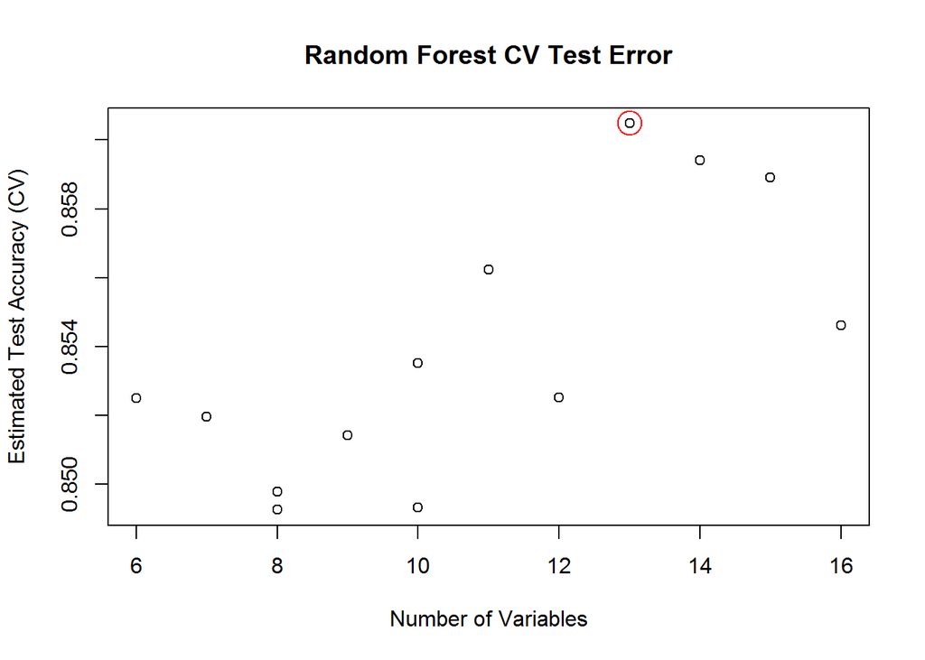

```r
varnumber = rowSums(as.matrix(resultsmtx[,1:16]))
plot(varnumber, resultsmtx$Accuracy, xlab = "Number of Variables", ylab = "Estimated Test Accuracy (CV)", main = "Random Forest CV Test Error")
points(varnumber[which.max(resultsmtx$Accuracy)], resultsmtx$Accuracy[which.max(resultsmtx$Accuracy)], col="red", cex=2.5)
```

```r
#Note maximum at 13 variables, our optimal model found above
```

### 3.2

Our criterion for choosing this model was to maximize prediction accuracy, so we have already made this estimation. Based on the cross validation above, we would expect our model to have accuracy in prediction of approximately $86.05\%$ (implying prediction error of $13.95\%$)

```r
#estimated accuracy of optimal model:
resultsmtx$Accuracy[which.max(resultsmtx$Accuracy)]
```

```
## [1] 0.8604784
```

```r
#estimated error rate:
resultsmtx$Error[which.min(resultsmtx$Error)]
```

```
## [1] 0.1395216
```

It is worth noting that logistic regression yields a NARROWLY greater predicted test error in far less computing time. It may be worth using the logistic regression predictor alongside the random forest because the performance is so similar. However, we report our minimum as our final model. To summarize, this model is:

```r
finalmoddf = druguse[,c(finalmodvars, "UseLevel")]
final_mod = randomForest(UseLevel ~ ., data=finalmoddf, ntree=550)
final_mod
```

```
##
## Call:
##  randomForest(formula = UseLevel ~ ., data = finalmoddf, ntree = 550)
##                Type of random forest: classification
##                      Number of trees: 550
## No. of variables tried at each split: 3
##
##         OOB estimate of  error rate: 14.54%
## Confusion matrix:
##      low high class.error
## low  703  146   0.1719670
## high 128  908   0.1235521
```